Life Sciences hackathon · built with Claude

# Reading pigmentation as a gene network

From one gibbon's out-of-place light patch to a selection scan across **117 primate genomes** — a walkthrough of what I built this week.

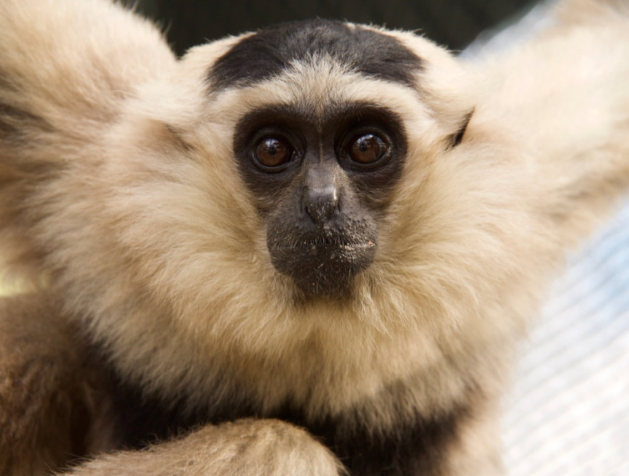

**Howard**, a pileated gibbon at the [Gibbon Conservation Center](https://www.gibboncenter.org/list-of-gcc-gibbons.html), Santa Clarita, CA.

The question that started it

## Why does Howard look “wrong”?

An adult male pileated gibbon should be almost completely **black** — like Truman. Howard isn't. He keeps a persistent patch of **light hair** on his back, and still reads a little more like a female of his species, like Tuk, who shares his enclosure.

The reason is almost too good: Howard had serious FOMO about the little treats Tuk was getting, and one day he grabbed one before anyone could stop him. Those treats were hormonal contraceptives — birth control. And his coat changed.

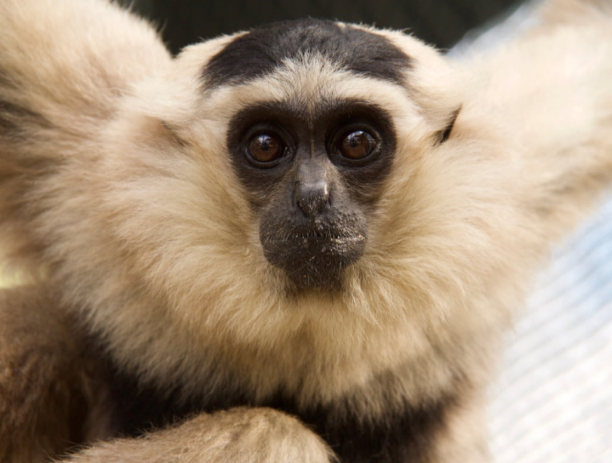

**Howard** — not like the other male gibbons

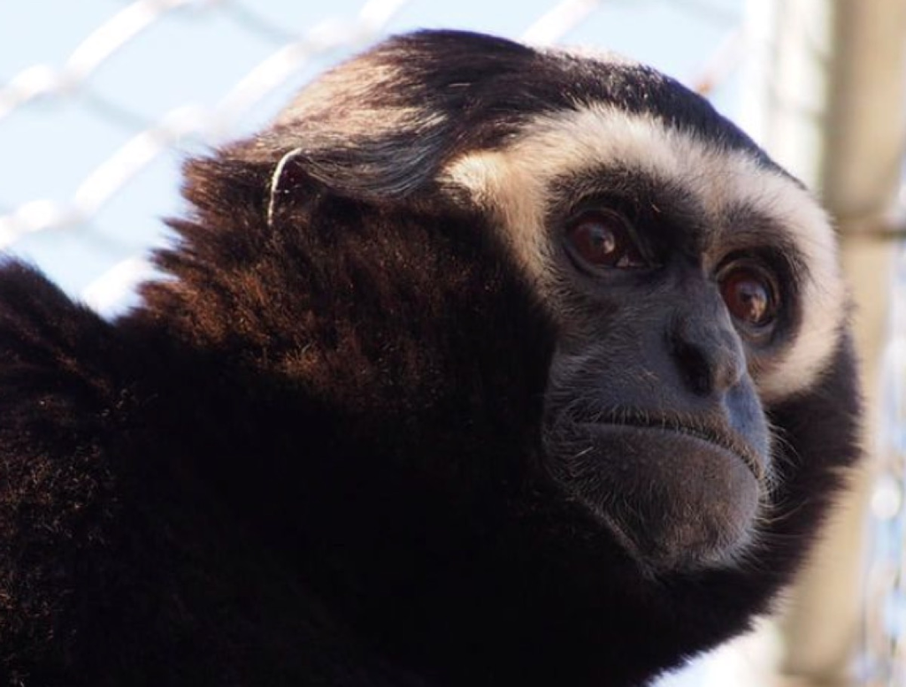

**Truman** — a typical adult male

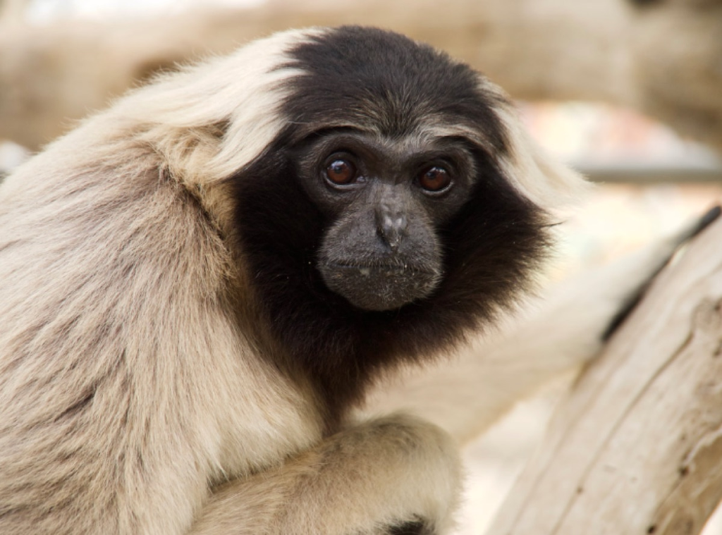

**Tuk** — an adult female

Hormones reached in and changed pigmentation. That's the whole reason I study this: pigmentation is a beautiful biological system that does **unexpected** things — and it talks to **other** systems. This week I set out to map that.

Act 1 · The network

## Pigmentation is polygenic — so which genes matter?

Lots of genes drive pigmentation, and picking the ones we should care about is not simple. So I started from a **literature-curated melanogenesis pathway** — how keratinocytes (skin cells) and melanocytes (pigment cells) signal — and used Claude to query database after database, working *backwards* from that molecular signaling to build out the genes involved while keeping the pathway's **directionality**.

The result is a multi-layer network across 5 functional layers — now the first stop for students in my lab to learn which gene interactions actually matter for our research. Claude Code + Claude Science turned it into an immersive, database-linked app.

[interactive chart not shown]

The 5-layer pigmentation network — drag to rotate, scroll to zoom, hover a gene to trace it through its layers. [Open full screen ↗](https://pigmentation-gene-network.vercel.app/)

[Explore the network →](https://pigmentation-gene-network.vercel.app/) [Resolve to genes →](https://tinalasisi.github.io/pigmentation-gene-network/notebooks/02_resolve_network_to_genes.html) [Harmonized substrate →](https://tinalasisi.github.io/pigmentation-gene-network/notebooks/07_harmonized_substrate.html)

Act 2 · Coupling the hormones

## Wiring the sex-hormone axis into pigmentation

Because of Howard, I wanted hormones in the picture. I pulled the sex-hormone gene set from KEGG — steroid-hormone biosynthesis and GnRH signaling — and used STRING to draw how those hormone genes wire into the pigmentation network. The result is a **coupled network**: a concrete map of how sex hormones are known to touch pigmentation genes through documented pathways.

[interactive chart not shown]

The coupled network — pigmentation genes (warm) and the sex-hormone genes wired into them (cool). [Open full screen ↗](https://tinalasisi.github.io/pigmentation-gene-network/interactive/coupled_network_3d.html)

[Sex-hormone layer →](https://tinalasisi.github.io/pigmentation-gene-network/notebooks/13_sex_hormone_layer.html) [Gene panel · two coupled networks →](https://tinalasisi.github.io/pigmentation-gene-network/networks.html#the-coupled-pigmentationhormone-network)

Act 3 · The evolution test

## Does any of this show up across evolution?

To find out, I built a **phylogenetic bioinformatics pipeline** and ran it on the cluster. These 7 steps run for **all 110 genes** (pigmentation + hormone), each across **117 primate species**:

1. 1

### 🧬 Download the genomes NCBI

   The full DNA of 117 primate species (~700 GB) — each genome ~2.6–3 billion letters.
2. 2

### ✂️ Find & cut out each gene miniprot

   Locate each gene inside every genome and extract its DNA — matching the human protein where there's no gene map.
3. 3

### 📊 Line the copies up MAFFT

   Stack all 117 species' versions of a gene so matching positions align.
4. 4

### 🌳 Bring in the family tree phylogeny

   Use the primate tree so the math accounts for shared ancestry — close cousins resemble each other for free.
5. 5

### 🔬 Test for selection RELAXaBSREL

   For each gene, ask whether natural selection is intensified in dichromatic species, and on which lineages.
6. 6

### 🔀 Compare the independent origins per-origin

   Dichromatism arose ~15 times — did evolution reuse the same genes, or different ones?
7. 7

### 📋 Collect & label results

   Every gene's selection stats, tagged by functional group, into readable tables.

✓

It all runs **in parallel** on Michigan's Great Lakes supercomputer — total time equals the single slowest gene, not the sum. And every step is **checked**: a job saying "done" isn't the same as a job being right.

Act 3 · What came out

## Same trait as birds — completely different genetics

In birds, sexual color differences have often been traced to **individual pigment genes** — different lineages, different genes (*MC1R* in some, *BCO2* in others). Primates don't work that way. Across the primate tree, dichromatism arose about **15 separate times**, and it's **lost roughly nine times faster than it's gained** — a disposable, polygenic trait, not a fixed switch.

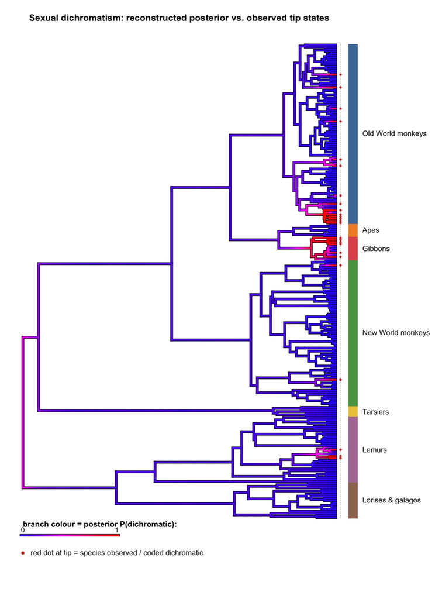

Dichromatism painted across the primate tree — scattered origins, frequent reversals. [see the full analysis](https://tinalasisi.github.io/pigmentation-gene-network/notebooks/15_dichromatism_synthesis.html)

Same phenotype you'd see in a dimorphic bird — but the genetics underneath are nothing alike. In primates the signal is **spread across many genes** in the pathway rather than concentrated in a single one: a completely different genetic architecture.

One last thread — the one that started with Howard. On the hormone side, a steroid-metabolism gene, **AKR1C4**, is a **suggestive** cross-species signal (preliminary — 24 dichromatic species). If it holds, it points right back to where hormones and pigmentation meet.

[Dichromatism synthesis →](https://tinalasisi.github.io/pigmentation-gene-network/notebooks/15_dichromatism_synthesis.html) [Cross-species GWAS →](https://tinalasisi.github.io/pigmentation-gene-network/notebooks/16_cross_species_gwas.html) [Dichromatism overview →](https://tinalasisi.github.io/pigmentation-gene-network/dichromatism.html)

What comes next · one case of many

## The instrument hands me the next question

Now that the whole pipeline exists, I can interrogate individual species that the analysis flags as surprising — something I simply couldn't do a week ago. Here is one that caught my eye. The leave-one-out reconstruction is the tell: of every monochromatic species on the tree, *Trachypithecus delacouri* — the Delacour's langur — is the **one** the phylogeny most expected to be dichromatic (predicted ~60%), because it sits inside the densest dichromatic radiation of langurs yet the adults are not sexually dichromatic.

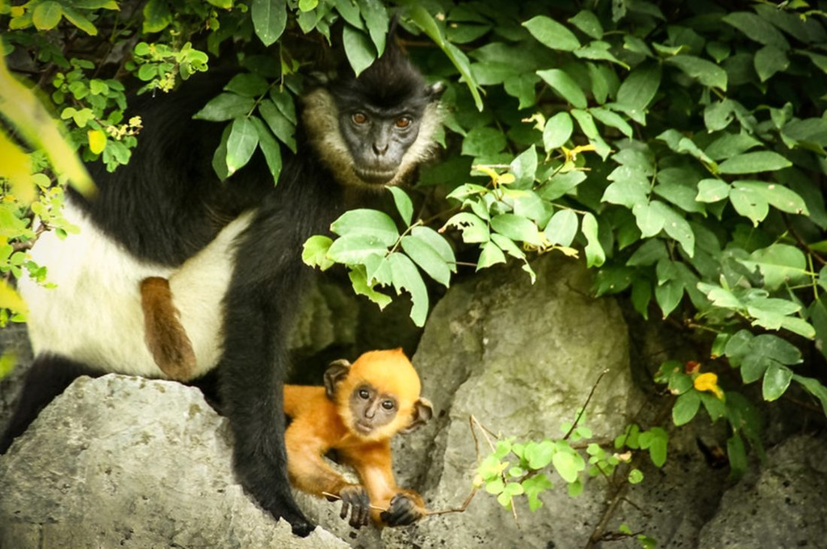

Adult *Trachypithecus delacouri* (black-and-white) with a **bright-orange infant** — the same species, a few months apart. Photo: [Flickr / 28707373@N08](https://www.flickr.com/photos/28707373@N08/16164893699/sizes/c/).

When I looked into it, the reason it reads as "almost dichromatic" turns out to be developmental, not sexual: its infants are born a **vivid orange** and darken to the black-and-white adult coat over the first months of life. So the trait my analysis is built to detect — a **hormone-linked change in pigmentation** — *is* present here; it just plays out **across development** rather than **between the sexes**. Natal-coat colour change and sexual dichromatism plausibly draw on the **same coupled pigment–hormone machinery**, switched on by a different signal. That is a hypothesis the reconstruction raised on its own, and one the pipeline is now set up to test — exactly the kind of lead I can chase because the instrument exists.

🔬

**Why this matters for the build.** This is not a headline result — it is a worked example of what the finished instrument makes askable. One reconstruction, one flagged species, one testable new hypothesis about where else the pigment–hormone coupling shows up. There are many more where this came from.

Explore everything

🏠 The full site

Overview, methods, and all 16 notebooks.

🕸️ The gene network

The 5-layer pigmentation network + hormone coupling.

🧬 The coupled panel

The 110-gene two-module panel, tested for selection.

🐒 Dichromatism synthesis

A labile, two-module trait across the primates.

📈 Cross-species GWAS

Phylogeny-controlled association — the AKR1C4 hit.

💻 The code

Everything on GitHub — pipeline, data provenance, notebooks.